# Does high team performance correlate with larger attendance for the 2023 NBA season?

## By: Jayne VanKirk

## Introduction

The research questions I am exploring in this analysis are:

Do higher-performing teams have a larger attendance?

If so, what statistics of a team play the most important role in determining team attendance?

The data for team performance is from an ISAR package and the dataset is called nba_ff_team_2023. The four factors (shooting, turnovers, rebounding, and free throws) will be used to determine how good a team is. Using Dean Oliver’s “Four Factors of Basketball Success”, an overall score will be computed using the following weights: Shooting(40%), Turnovers(25%), Rebounding(20%), and Free Throws(15%). Additionally, I will compare the average attendance for home games versus away games to see if there is a difference. This analysis could be used by teams to determine if attendance correlates with high-performance. If it does, they could work to improve performance in order to maximize profit off of attendance of live events.

## Setup

```r
## Final Project Data
library(tidyverse)
```

```r
library(ISAR)
library(ggplot2)
library(broom)
library(rvest)
library(ggrepel)
## NBA Attendance Report for 2023
attendance_url <- "https://www.espn.com/nba/attendance/_/year/2023"


## Scraping Attendance Data
attendance_table <- attendance_url %>%
  read_html() %>%
  html_elements("table") %>%
  html_table()

attendance_data <- attendance_table[[1]]

## Changing the column names
colnames(attendance_data) <- c("RK", "TEAM", "H_GMS", "H_TOTAL","H_AVG", "H_PCT", "R_GMS", "R_AVG", "R_PCT", "O_GMS", "O_AVG", "O_PCT")


# Removing the first two rows because they are the title of the columns from scraping the data
attendance_data <- attendance_data %>%
  slice(-c(1, 2))

## Removing the last two rows because it is invalid from scraping the data
attendance_data <- attendance_data %>%
  slice(1:(n()-2))

## Modifying nba_ff_team_2023 dataset
team_data <- nba_ff_team_2023 %>% group_by(team_name) %>%
  summarise(avg_efg = mean(efg_pct),
   avg_fta = mean(fta_rate),
   avg_tm_tov = mean(tm_tov_pct),
   avg_oreb = mean(oreb_pct)) %>%
  mutate(ff_performance = 0.4 * avg_efg + 0.25 * avg_tm_tov + 0.2 * avg_oreb + 0.15 * avg_fta)


## Combined the attendance and team_data data sets
attendance_and_performance <- team_data %>%
  left_join(attendance_data,
            by = join_by("team_name" == "TEAM") ) %>%
  na.omit()

## Had to convert the H_AVG and R_AVG variable to numeric
attendance_and_performance <- attendance_and_performance %>%
  mutate(H_AVG = as.numeric(gsub(",", "", H_AVG)))

attendance_and_performance <- attendance_and_performance %>%
  mutate(R_AVG = as.numeric(gsub(",", "", R_AVG)))
```

## Summary Statistics

```r
summary(attendance_and_performance$ff_performance)
```

```
##    Min. 1st Qu.  Median    Mean 3rd Qu.    Max.
##  0.3224  0.3314  0.3361  0.3355  0.3396  0.3481
```

```r
summary(attendance_and_performance$H_AVG)
```

```
##    Min. 1st Qu.  Median    Mean 3rd Qu.    Max.
##   15534   17123   17669   18031   19156   20527
```

```r
summary(attendance_and_performance$R_AVG)
```

```
##    Min. 1st Qu.  Median    Mean 3rd Qu.    Max.
##   17499   17755   18013   18063   18243   19772
```

Based on the summary statistics, the computed overall team performance across all of the teams is very similar. There isn’t a large range for that variable. The range for the average home attendance is larger than the range for the average away attendance but again, the spread isn’t very large. The summary statistics are indicating that there may not be much of a difference in attendance based on performance since the ranges are fairly small.

## Identifying the Top Teams in Attendance for Home and Away

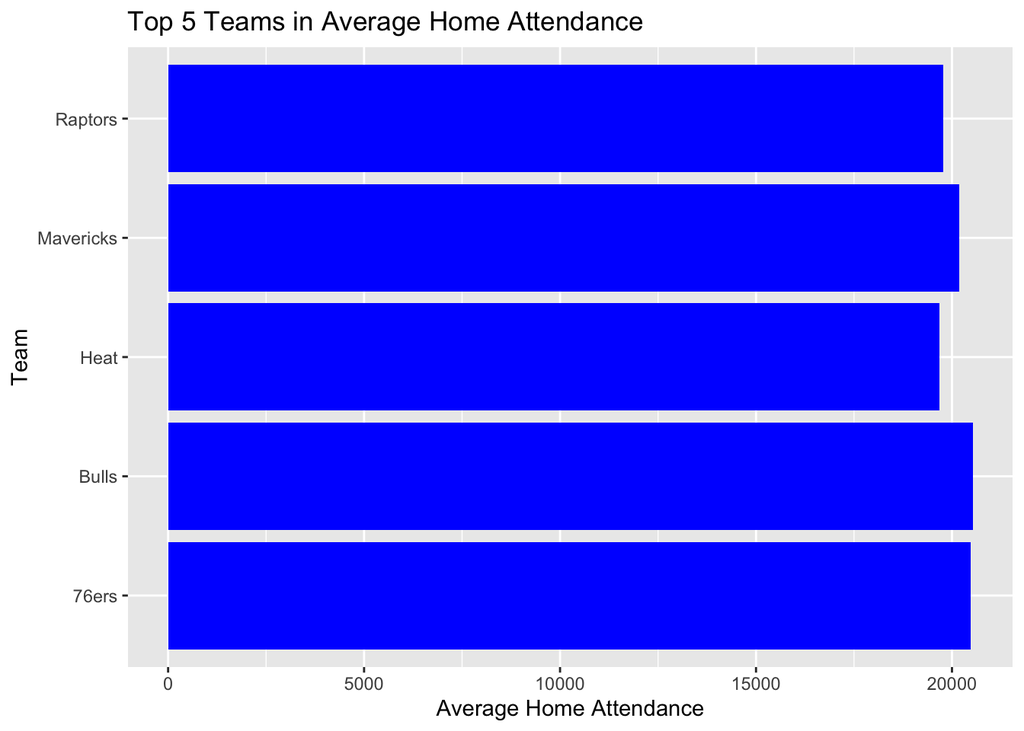

```r
## found the teams with the largest average home attendance
attendance_and_performance <- attendance_and_performance %>%
  arrange(desc(H_AVG)) %>%
  mutate(top_5_home_attendance = if_else(row_number() <= 5, team_name, ""))

## making a column for the top 5 in away attendance
attendance_and_performance <- attendance_and_performance %>%
  arrange(desc(R_AVG)) %>%
  mutate(top_5_away_attendance = if_else(row_number() <= 5, team_name, ""))

## Creating graphs for the top home teams and top away teams

# Created a data frame for top 5 teams in home attendance
top_5_home <- attendance_and_performance %>%
  filter(!is.na(top_5_home_attendance)) %>%
  arrange(desc(H_AVG)) %>%
  slice_head(n = 5)

# Created a data frame for top 5 teams in away attendance
top_5_away <- attendance_and_performance %>%
  filter(!is.na(top_5_away_attendance)) %>%
  arrange(desc(R_AVG)) %>%
  slice_head(n = 5)

# Create bar plots for top 5 teams in home and away attendance
 ggplot(top_5_home, aes(x = H_AVG, y = team_name)) +
  geom_bar(stat = "identity", fill = "blue") +
  labs(title = "Top 5 Teams in Average Home Attendance",
       x = "Average Home Attendance",
       y = "Team")
```

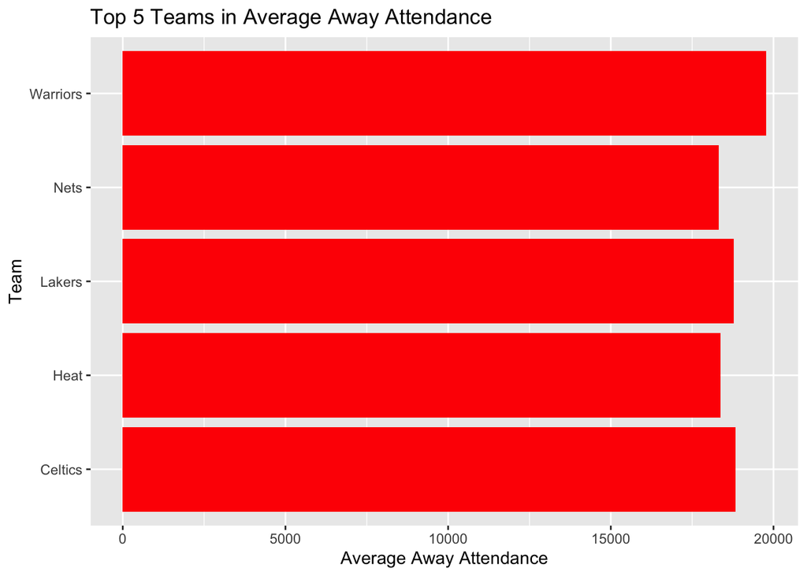

```r
 ggplot(top_5_away, aes(x = R_AVG, y = team_name)) +
  geom_bar(stat = "identity", fill = "red") +
  labs(title = "Top 5 Teams in Average Away Attendance",
       x = "Average Away Attendance",
       y = "Team")
```

Based on the graphs only the only team that was in the top five for average home and average away attendance was the Miami Heat.

## Analysis

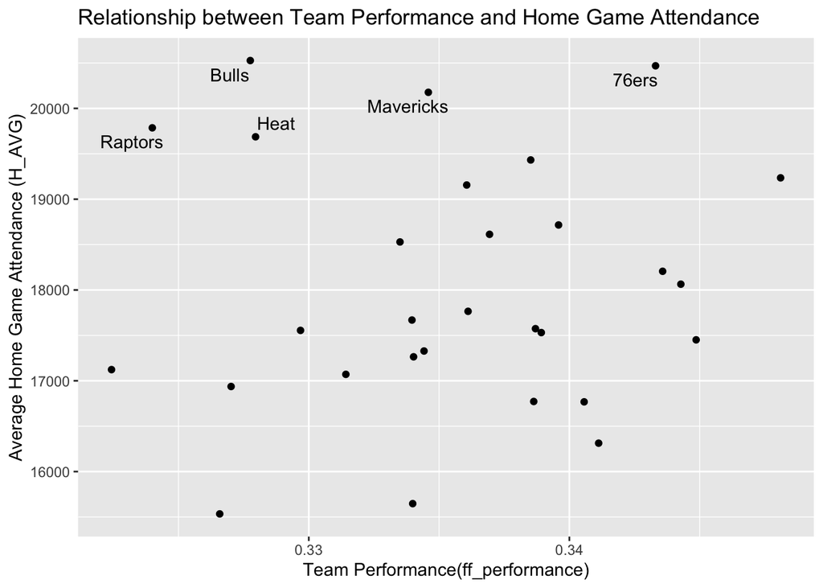

```r
## Scatterplot of average home attendance vs overall team performance
 attendance_and_performance %>% ggplot(aes(x = ff_performance, y = H_AVG)) + geom_point() +
  labs(
    title = "Relationship between Team Performance and Home Game Attendance",
    x = "Team Performance(ff_performance)",
    y = "Average Home Game Attendance (H_AVG)") +
  geom_text_repel(aes(label = top_5_home_attendance))
```

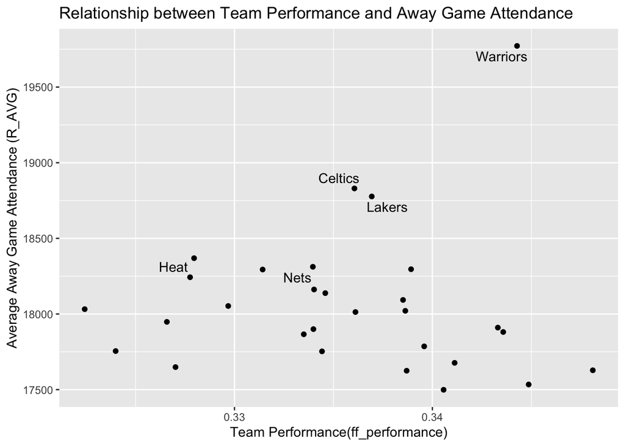

```r
 ## Scatterplot of average away attendance vs overall team performance
 attendance_and_performance %>% ggplot(aes(x = ff_performance, y = R_AVG)) + geom_point() +
  labs(
    title = "Relationship between Team Performance and Away Game Attendance",
    x = "Team Performance(ff_performance)",
    y = "Average Away Game Attendance (R_AVG)") +
  geom_text_repel(aes(label = top_5_away_attendance))
```

Based on the scatter plots, there doesn’t appear to be a trend in team performance vs attendance.

## Regression Models for Average Home and Away Attendance

```r
## regression for average home attendance
reg_attendance_home_performance <- lm(H_AVG~ avg_efg + avg_fta + avg_tm_tov+ avg_oreb , data = attendance_and_performance)
summary(reg_attendance_home_performance)
```

```
##
## Call:
## lm(formula = H_AVG ~ avg_efg + avg_fta + avg_tm_tov + avg_oreb,
##     data = attendance_and_performance)
##
## Residuals:
##      Min       1Q   Median       3Q      Max
## -2576.29  -687.48   -18.83   884.28  2195.89
##
## Coefficients:
##             Estimate Std. Error t value Pr(>|t|)
## (Intercept)    11706      13507   0.867    0.395
## avg_efg        17985      18275   0.984    0.335
## avg_fta        13346      12517   1.066    0.297
## avg_tm_tov    -40425      26412  -1.531    0.139
## avg_oreb       -7306      16234  -0.450    0.657
##
## Residual standard error: 1283 on 24 degrees of freedom
## Multiple R-squared:  0.2355, Adjusted R-squared:  0.1081
## F-statistic: 1.849 on 4 and 24 DF,  p-value: 0.1524
```

```r
## regression for average away attendance
reg_attendance_away_performance <- lm(R_AVG~ avg_efg + avg_fta + avg_tm_tov+ avg_oreb , data = attendance_and_performance)
summary(reg_attendance_away_performance)
```

```
##
## Call:
## lm(formula = R_AVG ~ avg_efg + avg_fta + avg_tm_tov + avg_oreb,
##     data = attendance_and_performance)
##
## Residuals:
##     Min      1Q  Median      3Q     Max
## -686.27 -140.92   -6.15  153.77 1195.73
##
## Coefficients:
##             Estimate Std. Error t value Pr(>|t|)
## (Intercept)    19187       4743   4.045  0.00047 ***
## avg_efg         2845       6417   0.443  0.66151
## avg_fta        -8892       4395  -2.023  0.05433 .
## avg_tm_tov      4229       9274   0.456  0.65252
## avg_oreb       -4159       5700  -0.730  0.47268
## ---
## Signif. codes:  0 '***' 0.001 '**' 0.01 '*' 0.05 '.' 0.1 ' ' 1
##
## Residual standard error: 450.5 on 24 degrees of freedom
## Multiple R-squared:  0.1935, Adjusted R-squared:  0.05911
## F-statistic:  1.44 on 4 and 24 DF,  p-value: 0.2515
```

The four factors were used in the models to see if the overall computed variable was inefective in predicting attendance. Neither regression model showed statistically significant p-values for any of the four factor variables to be used in predicting average home attendance or average away attendance for teams. Additionally, both models ended up with small adjusted r-squared values for the models with .10 for home and .05 for away.

## Conclusion

Based on the scatter plots and regression models using the four factors of a team’s performance, the attendance of home or away games is not correlated with team performance. The scatter plots showed that there wasn’t any trend in the data whether that was negative or positive. Additionally, the regression models used to predict home and away attendance were not statistically significant and weren’t able to account for much of the variability in the data.

Next steps could be changing the data set for team performance by using different variables to measure performance such as number of wins. Additionally, individual player performance could be a factor in attendance of games so an analysis could be ran based on the number of high-performing players are on the team versus the attendance of their games. Understanding what drives the attendance of basketball games could boost team earnings by making the games more profitable.